# Lab 9

Jahiya Clark

11/13/2021

# Brown Creeper Chi- Square Test

```r
require(here)
birds   = read.csv(here("data", "bird.sta.csv"))
hab     = read.csv(here("data", "hab.sta.csv"))
birdhab = merge(birds, hab, by=c("basin", "sub", "sta"))
br_creeper_table = table(birdhab$s.edge, birdhab$BRCR > 0)[, 2:1]

chisq.test(br_creeper_table)
```

```
##
##  Pearson's Chi-squared test with Yates' continuity correction
##
## data:  br_creeper_table
## X-squared = 23.3, df = 1, p-value = 1.386e-06
```

# Question 1

There is no significant relationship between brown creeper presence or absence and forest interior or forest edge.

# Question 2

My chi square value is 23.3, which is high, and my p value is 1.386e^-6, which is less than significance value of 0.05. Thus I can reject the null hypothesis. The two variables are dependent and have a relationship. I do believe brown creepers show a habitat preference for the interior of forest after also doing prop.test.

```r
prop.test(c(29, 314), c(173, 873),
          alternative = c("less"))
```

```
##
##  2-sample test for equality of proportions with continuity correction
##
## data:  c(29, 314) out of c(173, 873)
## X-squared = 23.3, df = 1, p-value = 6.929e-07
## alternative hypothesis: less
## 95 percent confidence interval:
##  -1.000000 -0.134773
## sample estimates:
##    prop 1    prop 2
## 0.1676301 0.3596793
```

# Building Models for ANOVA

```r
require(palmerpenguins)
fit_fl_sp =
  lm(
    formula = flipper_length_mm ~ species,
    data = penguins)
```

# Question 3

```r
fit_species <-
  lm(
    formula = penguins$body_mass_g ~ penguins$species
  )
```

# Question 4

```r
fit_sex <-
  lm(
    formula = penguins$body_mass_g ~ penguins$sex)
```

# Question 5

```r
fit_both <-
  lm(
    formula = penguins$body_mass_g ~ penguins$species * penguins$sex
  )
```

# Question 6

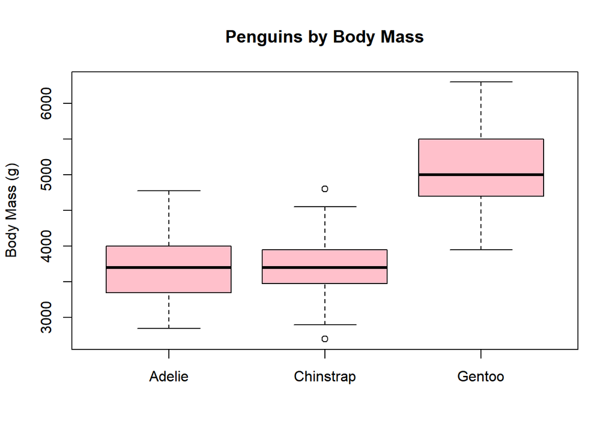

```r
boxplot(
  formula(fit_species),
  main = "Penguins by Body Mass",
  ylab = "Body Mass (g)",
  xlab = "",
  col = "pink"
)
```

# Question 7

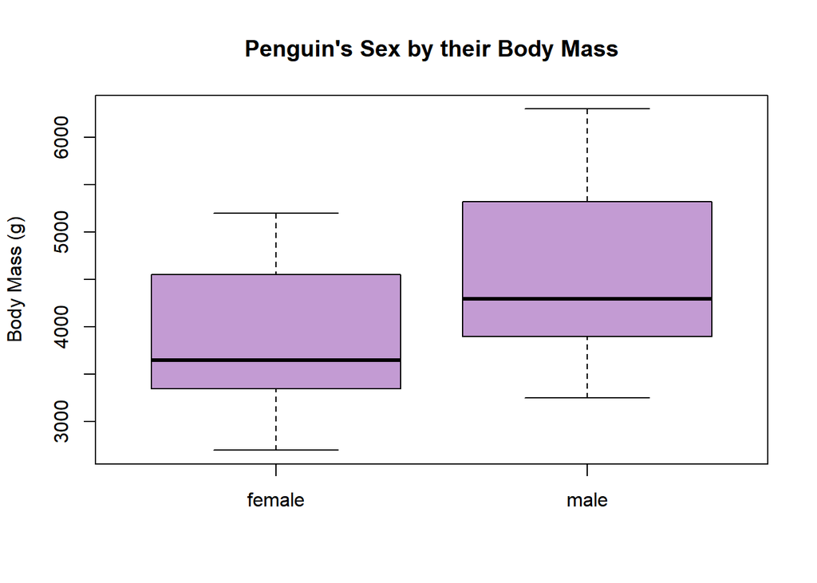

```r
boxplot(
  formula(fit_sex),
  main = "Penguin's Sex by their Body Mass",
  ylab = "Body Mass (g)",
  xlab = "",
  col = "#C39BD3"
)
```

# Question 8

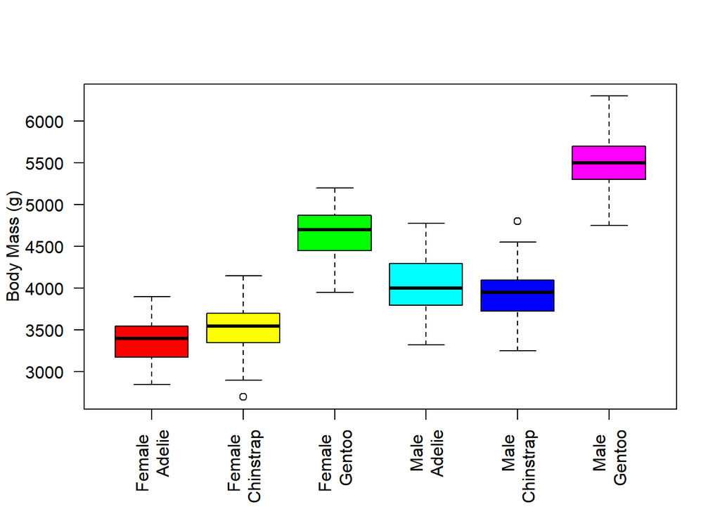

```r
boxplot(
  formula(fit_both),
  ylab = "Body Mass (g)",
  xlab = "",
  names = c("Female \nAdelie", "Female \nChinstrap",
            "Female \nGentoo", "Male \nAdelie", "Male \nChinstrap",
            "Male \nGentoo"),las= 2,
  col = rainbow(6)
)
```

# Question 9

I think the fit_species model will have a problem with the homogeneity assumption because the Adelie and Chinstrap boxes are very similar. Additionally, because of that my model fit_both might have a problem as well.

# Question 10

The null hypothesis of a Bartlett test is that the sample variances are the same.

# Question 11

The p-value is 0.0500

```r
bartlett.test(penguins$body_mass_g ~ penguins$species)
```

```
##
##  Bartlett test of homogeneity of variances
##
## data:  penguins$body_mass_g by penguins$species
## Bartlett's K-squared = 5.9895, df = 2, p-value = 0.05005
```

# Question 12

The p-value is 0.0319

```r
bartlett.test(penguins$body_mass_g ~ penguins$sex)
```

```
##
##  Bartlett test of homogeneity of variances
##
## data:  penguins$body_mass_g by penguins$sex
## Bartlett's K-squared = 4.6017, df = 1, p-value = 0.03194
```

# Question 13

The p-value of from the Bartlett test of homogeneity for observations of body mass (g) grouped by sex was 0.03194 and species was 0.05005.

```r
sex_group = aggregate(
  body_mass_g ~ sex,
  data = penguins,
  FUN = c)

sp_group = aggregate(
  body_mass_g ~ species,
  data = penguins,
  FUN = c)

bartlett.test(sex_group$body_mass_g)
```

```
##
##  Bartlett test of homogeneity of variances
##
## data:  sex_group$body_mass_g
## Bartlett's K-squared = 4.6017, df = 1, p-value = 0.03194
```

```r
bartlett.test(sp_group$body_mass_g)
```

```
##
##  Bartlett test of homogeneity of variances
##
## data:  sp_group$body_mass_g
## Bartlett's K-squared = 5.9895, df = 2, p-value = 0.05005
```

# Question 14

After conducting the Bartlett test for homogeneity, I found some issue with the test comparing body mass by species. Because the p-value is 0.05005 I will not reject the null hypothesis. The cutoff of 0.05 is to me not equal to or less than but just less than 0.05 to be significant.